# DNN_LSTM_classification_reuters

## reuters 데이터셋을 기반으로 한 DNN, LSTM 모델의 카테고리 분류

### Classification Categories about reuters letters with DNN and LSTM models

- **임규연 (가천대학교 컴퓨터공학부 학부과정, 서울대학교 의생명정보학연구실 학부인턴)**
  - 학번 : 202334734
  - e-mail : lky473736@gmail.com
  - GitHub : https://github.com/lky473736
  - 관심 분야 : Artificial Intelligence, AI for Signal Data, Time-Series Self-Supervised Learning, Human Activity Recognition
- **Keyword** : Classification, Reuters, Dense, LSTM

### - abstract -

[output not shown]

### 1. introduction

- 데이터 출처: Keras 내장 데이터셋 (tensorflow.keras.datasets.reuters)
- 문제 유형: 다중 클래스 분류 (multi-class classification)
- 특징 (Input): 정수로 인코딩된 단어 시퀀스
- 타겟 (Output): 0~45 사이의 정수 라벨 (One-hot 인코딩 처리)
- 모델: DNN (다층 퍼셉트론), LSTM (순환 신경망)
- 목적: 뉴스 기사 본문을 기반으로 주제를 정확히 분류하는 분류기 구현 및 성능 비교

본 DNN, LSTM 모델을 구현할 테크는 아래와 같다.

- **데이터 읽기 및 전처리 테크닉** : pandas
- **모델링 및 머신러닝-딥러닝 라이브러리** : scikit-learn, TensorFlow, Keras
- **선형대수학 및 tensor 이용** : numpy
- **데이터 시각화** : matplotlib, seaborn

데이터 분석은 아래와 같은 단계로 진행된다.

- **1) 데이터 구조 파악 및 전처리, 시각화**
  - 데이터의 구조 및 기초 통계량 확인, 특정 attribute에 대한 간단한 시각화를 진행한다.
- **2) DNN 기반의 classification 진행 및 성능 지표 출력, 시각화**
- **3) LSTM 기반의 classification 진행 및 성능 지표 출력, 시각화**

```python
import pandas as pd
import matplotlib.pyplot as plt
import seaborn as sns
import sklearn as sk
import numpy as np
import tensorflow as tf
import tensorflow.keras as keras

import numpy as np
import matplotlib.pyplot as plt
import seaborn as sns
from tensorflow.keras.datasets import reuters
from tensorflow.keras.preprocessing.sequence import pad_sequences
from tensorflow.keras.utils import to_categorical
from tensorflow.keras.models import Sequential
from tensorflow.keras.layers import Embedding, LSTM, Dense, GRU
from tensorflow.keras.callbacks import EarlyStopping
```

### 2. 데이터 구조 파악 및 전처리, 시각화

- 본 단계에서는 데이터의 기초적인 통계량 파악, 데이터 전처리 및 각 attribute에 대한 시각화를 진행한다.

```python
# 데이터 불러오기
(x_train, y_train), (x_test, y_test) = reuters.load_data(num_words=10000, test_split=0.3)

print(f"훈련 데이터 개수: {len(x_train)}")
print(f"테스트 데이터 개수: {len(x_test)}")

print("기사 샘플 (정수 시퀀스):", x_train[0])
print("카테고리:", y_train[0])
```

```
훈련 데이터 개수: 7859
테스트 데이터 개수: 3369
기사 샘플 (정수 시퀀스): [1, 2, 2, 8, 43, 10, 447, 5, 25, 207, 270, 5, 3095, 111, 16, 369, 186, 90, 67, 7, 89, 5, 19, 102, 6, 19, 124, 15, 90, 67, 84, 22, 482, 26, 7, 48, 4, 49, 8, 864, 39, 209, 154, 6, 151, 6, 83, 11, 15, 22, 155, 11, 15, 7, 48, 9, 4579, 1005, 504, 6, 258, 6, 272, 11, 15, 22, 134, 44, 11, 1…
카테고리: 3
```

해당 코드를 실행한 결과를 통해 우리는 로이터 뉴스 데이터셋에 대한 기본적인 구조와 내용을 파악할 수 있다. 먼저 훈련 데이터는 7,859개, 테스트 데이터는 3,369개로 총 11,228개의 뉴스 기사가 있으며, **이 중 약 70%가 모델 학습에 사용되고, 나머지 30%가 성능 평가를 위한 테스트용**으로 분리되어 있음을 알 수 있다.

또한 x_train[0]의 출력 결과를 보면 뉴스 기사 한 편이 정수 시퀀스로 표현되어 있는 것을 확인할 수 있다. 이는 **각 단어가 고유한 정수로 매핑된 형태로, 신경망 모델이 텍스트를 처리할 수 있도록 숫자 형태로 변환**된 것이다. 예를 들어 [1, 2, 2, 8, 43, 10, ...] 와 같은 시퀀스는 원래 문장의 단어들이 정수 인덱스로 바뀐 것인데, 여기서 num_words=10000 옵션을 통해 상위 10,000개의 단어만을 사용하도록 제한하고 있다.

마지막으로 출력된 y_train[0] = 3 은 해당 뉴스 기사의 카테고리 라벨을 의미한다. 로이터 데이터셋은 총 46개의 뉴스 카테고리로 구성되어 있으며, 이 정수값은 그중 하나의 클래스를 나타낸다. 즉, 이 기사는 3번 카테고리에 속해 있음을 알 수 있으며, 이는 모델이 입력된 기사에 대해 분류를 수행해야 할 정답 레이블로 사용된다. 이처럼 간단한 출력만으로도 데이터의 구조, 표현 방식, 분류 문제의 형태 등을 이해할 수 있다.

```
{0, 1, 2, 3, 4, 5, 6, 7, 8, 9, 10, 11, 12, 13, 14, 15, 16, 17, 18, 19, 20, 21, 22, 23, 24, 25, 26, 27, 28, 29, 30, 31, 32, 33, 34, 35, 36, 37, 38, 39, 40, 41, 42, 43, 44, 45}
```

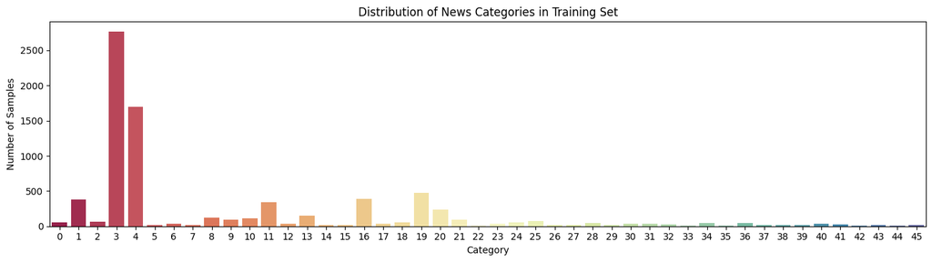

```python
import matplotlib.pyplot as plt
import seaborn as sns
import pandas as pd
import numpy as np

train_labels = pd.DataFrame(y_train, columns=['category'])
print (set(y_train))

plt.figure(figsize=(14, 4))
sns.countplot(x='category', data=train_labels, palette='Spectral')
plt.title("Distribution of News Categories in Training Set")
plt.xlabel("Category")
plt.ylabel("Number of Samples")
plt.tight_layout()
plt.show()
```

각각의 번호에 해당되는 카테고리는 다음과 같다.

[output not shown]

```python
print("뉴스 기사 최대 길이:", max(len(x) for x in x_train))
print("뉴스 기사 평균 길이:", np.mean([len(x) for x in x_train]))
```

```
뉴스 기사 최대 길이: 2246
뉴스 기사 평균 길이: 146.07914492938033
```

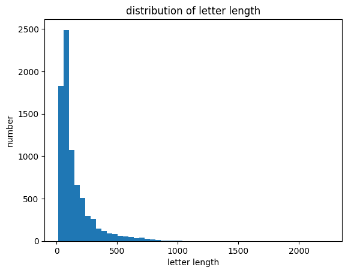

```
'\n    대부분이 매우 짧은 기사로 이루어졌음을 알 수 있다.\n'
```

```python
plt.hist([len(x) for x in x_train], bins=50)
plt.xlabel("letter length")
plt.ylabel("number")
plt.title("distribution of letter length")
plt.show()

'''
    대부분이 매우 짧은 기사로 이루어졌음을 알 수 있다.
'''
```

```python
max_len = 100  # 적당한 최대 길이로 자름
x_train = pad_sequences(x_train, maxlen=max_len)
x_test = pad_sequences(x_test, maxlen=max_len)

y_train = to_categorical(y_train)
y_test = to_categorical(y_test)
```

### 3. DNN 기반의 Classification 진행 및 성능 지표 출력, 시각화

[figure not shown]

**DNN (Deep Neural Network)** 은 여러 개의 은닉층(hidden layer)을 쌓아 깊게 만든 인공신경망 모델로, 입력 데이터의 복잡한 패턴을 학습하는 데 효과적이다. 각 은닉층은 여러 개의 뉴런으로 구성되고, 이전 층의 출력을 가중합 후 비선형 함수에 통과시켜 다음 층으로 전달한다. 하지만 DNN은 순차적 시간 정보를 고려하지 않기 때문에, 시계열 데이터의 시간적 연속성과 장기 의존성을 학습하기에 한계가 있다.

시계열 데이터에 DNN을 사용하는 경우 고려해야 할 점은 다음과 같다.

- **시간 순서 무시** → DNN은 입력을 고정된 길이 벡터로 처리하므로, 시간적 순서가 보존되지 않아 시계열 특성을 반영하지 못한다.
- **단기 패턴 학습에 제한적** → 데이터 내 단기적 특징은 학습 가능하지만, 장기적인 의존 관계는 반영하지 못한다.
- **복잡한 시퀀스 맥락 반영 어려움** → 시계열의 흐름이나 패턴 변화가 중요한 문제에서는 성능 저하가 발생할 수 있다.

따라서, 시계열 데이터 예측에서 DNN은 간단한 벡터 형태의 입력을 처리하는 데 유리하지만, 장기적이고 시간 의존적인 정보를 필요로 하는 문제에서는 LSTM 같은 순환 신경망이 더 적합하다. LSTM 실험은 추후 4번에서 진행한다.

```python
(x_train_orig, y_train), (x_test_orig, y_test) = reuters.load_data(num_words=10000, test_split=0.3)
y_train_cat = to_categorical(y_train)
y_test_cat = to_categorical(y_test)

tokenizer = Tokenizer(num_words=10000)
x_train_binary = tokenizer.sequences_to_matrix(x_train_orig, mode='binary')
x_test_binary = tokenizer.sequences_to_matrix(x_test_orig, mode='binary')

# DNN model 구축
dnn_model = Sequential([
    Dense(128, activation='relu', kernel_regularizer=regularizers.l2(0.001),
         input_shape=(10000,)),
    BatchNormalization(),
    Dropout(0.2),
    Dense(128, activation='relu', kernel_regularizer=regularizers.l2(0.001)),
    BatchNormalization(),
    Dropout(0.2),
    Dense(46, activation='softmax')
])

dnn_model.summary()
```

```
Model: "sequential_22"
```

```
┏━━━━━━━━━━━━━━━━━━━━━━━━━━━━━━━━━┳━━━━━━━━━━━━━━━━━━━━━━━━┳━━━━━━━━━━━━━━━┓
┃ Layer (type)                    ┃ Output Shape           ┃       Param # ┃
┡━━━━━━━━━━━━━━━━━━━━━━━━━━━━━━━━━╇━━━━━━━━━━━━━━━━━━━━━━━━╇━━━━━━━━━━━━━━━┩
│ dense_64 (Dense)                │ (None, 128)            │     1,280,128 │
├─────────────────────────────────┼────────────────────────┼───────────────┤
│ batch_normalization_38          │ (None, 128)            │           512 │
│ (BatchNormalization)            │                        │               │
├─────────────────────────────────┼────────────────────────┼───────────────┤
│ dropout_40 (Dropout)            │ (None, 128)            │             0 │
├─────────────────────────────────┼────────────────────────┼───────────────┤
│ dense_65 (Dense)                │ (None, 128)            │        16,512 │
├─────────────────────────────────┼────────────────────────┼───────────────┤
│ batch_normalization_39          │ (None, 128)            │           512 │
│ (BatchNormalization)            │                        │               │
├─────────────────────────────────┼────────────────────────┼───────────────┤
│ dropout_41 (Dropout)            │ (None, 128)            │             0 │
├─────────────────────────────────┼────────────────────────┼───────────────┤
│ dense_66 (Dense)                │ (None, 46)             │         5,934 │
└─────────────────────────────────┴────────────────────────┴───────────────┘
```

```
 Total params: 1,303,598 (4.97 MB)
```

```
 Trainable params: 1,303,086 (4.97 MB)
```

```
 Non-trainable params: 512 (2.00 KB)
```

각 Dense 레이어 뒤에 Batch Normalization과 Dropout을 추가하였다. 첫 번째 Dense 층은 128개의 유닛을 가지며 활성화 함수로 ReLU를 사용하였다. 이 층 뒤에 Batch Normalization을 적용하여 학습 안정성을 높이고, Dropout(비율 0.2)을 적용하여 과적합을 방지하였다. 두 번째 Dense 층 또한 128개 유닛과 ReLU 활성화를 사용하며, 마찬가지로 Batch Normalization과 Dropout(비율 0.2)을 순차적으로 추가하였다. 이렇게 구성된 모델은 정규화와 드롭아웃 기법을 통해 학습 과정에서 과적합을 줄이고 일반화 성능을 향상시키는 데 도움이 된다.

```python
dnn_model.compile(optimizer=tf.optimizers.Adam(0.001),
                 loss='categorical_crossentropy',
                 metrics=['accuracy'])

dnn_history = dnn_model.fit(x_train_binary, y_train_cat, epochs=30,
                          batch_size=64, validation_split=0.2)
```

```
99/99 ━━━━━━━━━━━━━━━━━━━━ 4s 28ms/step - accuracy: 0.4659 - loss: 2.8047 - val_accuracy: 0.7188 - val_loss: 2.6357
99/99 ━━━━━━━━━━━━━━━━━━━━ 4s 43ms/step - accuracy: 0.8577 - loss: 0.9525 - val_accuracy: 0.7595 - val_loss: 1.8040
99/99 ━━━━━━━━━━━━━━━━━━━━ 3s 26ms/step - accuracy: 0.9326 - loss: 0.6240 - val_accuracy: 0.8015 - val_loss: 1.3055
99/99 ━━━━━━━━━━━━━━━━━━━━ 3s 25ms/step - accuracy: 0.9527 - loss: 0.5215 - val_accuracy: 0.8003 - val_loss: 1.2001
99/99 ━━━━━━━━━━━━━━━━━━━━ 3s 26ms/step - accuracy: 0.9583 - loss: 0.4627 - val_accuracy: 0.8053 - val_loss: 1.2576
99/99 ━━━━━━━━━━━━━━━━━━━━ 3s 27ms/step - accuracy: 0.9586 - loss: 0.4388 - val_accuracy: 0.7990 - val_loss: 1.2883
99/99 ━━━━━━━━━━━━━━━━━━━━ 3s 26ms/step - accuracy: 0.9665 - loss: 0.3962 - val_accuracy: 0.8130 - val_loss: 1.3323
99/99 ━━━━━━━━━━━━━━━━━━━━ 3s 26ms/step - accuracy: 0.9636 - loss: 0.3840 - val_accuracy: 0.8155 - val_loss: 1.2925
99/99 ━━━━━━━━━━━━━━━━━━━━ 2s 25ms/step - accuracy: 0.9709 - loss: 0.3638 - val_accuracy: 0.8117 - val_loss: 1.3567
99/99 ━━━━━━━━━━━━━━━━━━━━ 3s 26ms/step - accuracy: 0.9622 - loss: 0.3903 - val_accuracy: 0.8117 - val_loss: 1.3902
99/99 ━━━━━━━━━━━━━━━━━━━━ 3s 25ms/step - accuracy: 0.9656 - loss: 0.3673 - val_accuracy: 0.8098 - val_loss: 1.4148
99/99 ━━━━━━━━━━━━━━━━━━━━ 3s 25ms/step - accuracy: 0.9652 - loss: 0.3580 - val_accuracy: 0.8034 - val_loss: 1.3599
99/99 ━━━━━━━━━━━━━━━━━━━━ 3s 28ms/step - accuracy: 0.9702 - loss: 0.3504 - val_accuracy: 0.8066 - val_loss: 1.4160
99/99 ━━━━━━━━━━━━━━━━━━━━ 3s 29ms/step - accuracy: 0.9647 - loss: 0.3689 - val_accuracy: 0.8066 - val_loss: 1.4462
99/99 ━━━━━━━━━━━━━━━━━━━━ 3s 25ms/step - accuracy: 0.9633 - loss: 0.3705 - val_accuracy: 0.7952 - val_loss: 1.3909
99/99 ━━━━━━━━━━━━━━━━━━━━ 3s 26ms/step - accuracy: 0.9654 - loss: 0.3617 - val_accuracy: 0.8034 - val_loss: 1.4941
99/99 ━━━━━━━━━━━━━━━━━━━━ 3s 27ms/step - accuracy: 0.9621 - loss: 0.3544 - val_accuracy: 0.7945 - val_loss: 1.4062
99/99 ━━━━━━━━━━━━━━━━━━━━ 3s 28ms/step - accuracy: 0.9645 - loss: 0.3647 - val_accuracy: 0.8015 - val_loss: 1.5012
99/99 ━━━━━━━━━━━━━━━━━━━━ 3s 29ms/step - accuracy: 0.9675 - loss: 0.3570 - val_accuracy: 0.8060 - val_loss: 1.4629
99/99 ━━━━━━━━━━━━━━━━━━━━ 3s 28ms/step - accuracy: 0.9650 - loss: 0.3664 - val_accuracy: 0.7971 - val_loss: 1.5150
99/99 ━━━━━━━━━━━━━━━━━━━━ 3s 27ms/step - accuracy: 0.9667 - loss: 0.3704 - val_accuracy: 0.7983 - val_loss: 1.5106
99/99 ━━━━━━━━━━━━━━━━━━━━ 3s 30ms/step - accuracy: 0.9662 - loss: 0.3546 - val_accuracy: 0.8041 - val_loss: 1.5066
99/99 ━━━━━━━━━━━━━━━━━━━━ 3s 29ms/step - accuracy: 0.9690 - loss: 0.3421 - val_accuracy: 0.8066 - val_loss: 1.5326
99/99 ━━━━━━━━━━━━━━━━━━━━ 3s 29ms/step - accuracy: 0.9692 - loss: 0.3413 - val_accuracy: 0.7977 - val_loss: 1.5083
99/99 ━━━━━━━━━━━━━━━━━━━━ 3s 30ms/step - accuracy: 0.9647 - loss: 0.3625 - val_accuracy: 0.8034 - val_loss: 1.5161
99/99 ━━━━━━━━━━━━━━━━━━━━ 3s 29ms/step - accuracy: 0.9605 - loss: 0.3876 - val_accuracy: 0.8022 - val_loss: 1.5720
99/99 ━━━━━━━━━━━━━━━━━━━━ 3s 28ms/step - accuracy: 0.9637 - loss: 0.3863 - val_accuracy: 0.7869 - val_loss: 1.6541
99/99 ━━━━━━━━━━━━━━━━━━━━ 3s 27ms/step - accuracy: 0.9607 - loss: 0.4108 - val_accuracy: 0.7990 - val_loss: 1.6031
99/99 ━━━━━━━━━━━━━━━━━━━━ 3s 26ms/step - accuracy: 0.9658 - loss: 0.4007 - val_accuracy: 0.8003 - val_loss: 1.5650
99/99 ━━━━━━━━━━━━━━━━━━━━ 3s 28ms/step - accuracy: 0.9674 - loss: 0.3753 - val_accuracy: 0.7983 - val_loss: 1.5837
```

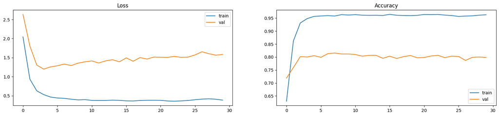

```python
plt.figure(figsize=(20, 4))

plt.subplot(1, 2, 1)
plt.plot(dnn_history.history['loss'], label='train')
plt.plot(dnn_history.history['val_loss'], label='val')
plt.title("Loss")
plt.legend()

plt.subplot(1, 2, 2)
plt.plot(dnn_history.history['accuracy'], label='train')
plt.plot(dnn_history.history['val_accuracy'], label='val')
plt.title("Accuracy")
plt.legend()

plt.show()
```

```python
y_pred_dnn_probs = dnn_model.predict(x_test_binary)
y_pred_dnn = np.argmax(y_pred_dnn_probs, axis=1)
y_true = np.argmax(y_test_cat, axis=1)

dnn_accuracy = accuracy_score(y_true, y_pred_dnn)
dnn_precision = precision_score(y_true, y_pred_dnn, average='macro')
dnn_recall = recall_score(y_true, y_pred_dnn, average='macro')
dnn_f1 = f1_score(y_true, y_pred_dnn, average='macro')

print(f"Accuracy: {dnn_accuracy:.4f}")
print(f"Precision (macro): {dnn_precision:.4f}")
print(f"Recall (macro): {dnn_recall:.4f}")
print(f"F1 Score (macro): {dnn_f1:.4f}")

print("\nClassification Report:\n", classification_report(y_true, y_pred_dnn))
```

```
106/106 ━━━━━━━━━━━━━━━━━━━━ 0s 2ms/step
Accuracy: 0.7881
Precision (macro): 0.6313
Recall (macro): 0.5085
F1 Score (macro): 0.5398

Classification Report:
               precision    recall  f1-score   support

           0       0.59      0.59      0.59        17
           1       0.73      0.80      0.77       159
           2       0.56      0.64      0.60        28
           3       0.91      0.93      0.92      1203
           4       0.84      0.87      0.85       722
           5       0.00      0.00      0.00         8
```

[output cut: 44 more lines]

위 모델은 현재 **overfitting** 되고 있다. 그 이유는 train accuracy는 매우 높으나, test accuracy는 비교적 낮고 train loss와 val loss가 많은 차이를 이루면서 val loss가 가볍게 우상향되는 것을 확인하였는는데, 이 현상으로 모델의 일반화 오류를 범하고 있음을 확인할 수 있다. network를 LSTM으로 변경하여도 이와 동일한 문제가 발생하는 지를 확인해보자.

### 4. LSTM 기반의 Classification 진행 및 성능 지표 출력, 시각화

```python
# 입력 데이터 형태 변경 (LSTM은 3D 입력 필요)
# (samples, features) -> (samples, timesteps, features)
x_train_reshaped = np.expand_dims(x_train_binary, axis=1)  # 1개의 timestep으로 처리
x_test_reshaped = np.expand_dims(x_test_binary, axis=1)

# 모델 파라미터
vocab_size = 10000
hidden_units = 128
num_classes = 46

model = Sequential()
model.add(LSTM(hidden_units, input_shape=(1, 10000)))
model.add(Dense(num_classes, activation='softmax'))

# 콜백 정의
es = EarlyStopping(monitor='val_loss', mode='min', verbose=1, patience=4)
mc = ModelCheckpoint('best_model.h5', monitor='val_accuracy', mode='max', verbose=1, save_best_only=True)

# 모델 컴파일
model.compile(loss='categorical_crossentropy', optimizer='adam', metrics=['accuracy'])

model.summary()
```

```
Model: "sequential_29"
```

```
┏━━━━━━━━━━━━━━━━━━━━━━━━━━━━━━━━━┳━━━━━━━━━━━━━━━━━━━━━━━━┳━━━━━━━━━━━━━━━┓
┃ Layer (type)                    ┃ Output Shape           ┃       Param # ┃
┡━━━━━━━━━━━━━━━━━━━━━━━━━━━━━━━━━╇━━━━━━━━━━━━━━━━━━━━━━━━╇━━━━━━━━━━━━━━━┩
│ lstm_7 (LSTM)                   │ (None, 128)            │     5,186,048 │
├─────────────────────────────────┼────────────────────────┼───────────────┤
│ dense_74 (Dense)                │ (None, 46)             │         5,934 │
└─────────────────────────────────┴────────────────────────┴───────────────┘
```

```
 Total params: 5,191,982 (19.81 MB)
```

```
 Trainable params: 5,191,982 (19.81 MB)
```

```
 Non-trainable params: 0 (0.00 B)
```

```python
history = model.fit(
    x_train_reshaped, y_train_cat,
    batch_size=128,
    epochs=30,
    callbacks=[es, mc],
    validation_data=(x_test_reshaped, y_test_cat)
)
```

```
62/62 ━━━━━━━━━━━━━━━━━━━━ 0s 60ms/step - accuracy: 0.5027 - loss: 2.8226
Epoch 1: val_accuracy improved from -inf to 0.71386, saving model to best_model.h5
```

[output not shown]

```
62/62 ━━━━━━━━━━━━━━━━━━━━ 6s 77ms/step - accuracy: 0.5043 - loss: 2.8116 - val_accuracy: 0.7139 - val_loss: 1.3079
61/62 ━━━━━━━━━━━━━━━━━━━━ 0s 60ms/step - accuracy: 0.7844 - loss: 1.0050
Epoch 2: val_accuracy improved from 0.71386 to 0.79400, saving model to best_model.h5
```

[output not shown]

```
62/62 ━━━━━━━━━━━━━━━━━━━━ 4s 67ms/step - accuracy: 0.7853 - loss: 1.0017 - val_accuracy: 0.7940 - val_loss: 0.9604
62/62 ━━━━━━━━━━━━━━━━━━━━ 0s 62ms/step - accuracy: 0.8974 - loss: 0.5364
Epoch 3: val_accuracy improved from 0.79400 to 0.80706, saving model to best_model.h5
```

[output not shown]

```
62/62 ━━━━━━━━━━━━━━━━━━━━ 4s 68ms/step - accuracy: 0.8975 - loss: 0.5359 - val_accuracy: 0.8071 - val_loss: 0.8468
62/62 ━━━━━━━━━━━━━━━━━━━━ 0s 61ms/step - accuracy: 0.9407 - loss: 0.3308
Epoch 4: val_accuracy improved from 0.80706 to 0.81419, saving model to best_model.h5
```

[output not shown]

```
62/62 ━━━━━━━━━━━━━━━━━━━━ 4s 69ms/step - accuracy: 0.9407 - loss: 0.3306 - val_accuracy: 0.8142 - val_loss: 0.8150
61/62 ━━━━━━━━━━━━━━━━━━━━ 0s 63ms/step - accuracy: 0.9554 - loss: 0.2123
Epoch 5: val_accuracy did not improve from 0.81419
62/62 ━━━━━━━━━━━━━━━━━━━━ 4s 70ms/step - accuracy: 0.9552 - loss: 0.2126 - val_accuracy: 0.8142 - val_loss: 0.8223
62/62 ━━━━━━━━━━━━━━━━━━━━ 0s 61ms/step - accuracy: 0.9636 - loss: 0.1547
Epoch 6: val_accuracy did not improve from 0.81419
62/62 ━━━━━━━━━━━━━━━━━━━━ 4s 68ms/step - accuracy: 0.9635 - loss: 0.1549 - val_accuracy: 0.8118 - val_loss: 0.8356
62/62 ━━━━━━━━━━━━━━━━━━━━ 0s 61ms/step - accuracy: 0.9612 - loss: 0.1357
Epoch 7: val_accuracy did not improve from 0.81419
62/62 ━━━━━━━━━━━━━━━━━━━━ 4s 67ms/step - accuracy: 0.9611 - loss: 0.1357 - val_accuracy: 0.8100 - val_loss: 0.8563
62/62 ━━━━━━━━━━━━━━━━━━━━ 0s 62ms/step - accuracy: 0.9665 - loss: 0.1020
Epoch 8: val_accuracy did not improve from 0.81419
62/62 ━━━━━━━━━━━━━━━━━━━━ 4s 68ms/step - accuracy: 0.9664 - loss: 0.1023 - val_accuracy: 0.8091 - val_loss: 0.8773
Epoch 8: early stopping
```

```python
y_pred_probs = model.predict(x_test_reshaped)
y_pred = np.argmax(y_pred_probs, axis=1)
y_true = np.argmax(y_test_cat, axis=1)

# 평가 지표 계산
from sklearn.metrics import confusion_matrix, classification_report
from sklearn.metrics import accuracy_score, precision_score, recall_score, f1_score
import matplotlib.pyplot as plt
import seaborn as sns

accuracy = accuracy_score(y_true, y_pred)
precision = precision_score(y_true, y_pred, average='macro')
recall = recall_score(y_true, y_pred, average='macro')
f1 = f1_score(y_true, y_pred, average='macro')

print(f"Accuracy: {accuracy:.4f}")
print(f"Precision (macro): {precision:.4f}")
print(f"Recall (macro): {recall:.4f}")
print(f"F1 Score (macro): {f1:.4f}")
print("\nClassification Report:\n", classification_report(y_true, y_pred))
```

```
106/106 ━━━━━━━━━━━━━━━━━━━━ 1s 5ms/step
Accuracy: 0.8091
Precision (macro): 0.7475
Recall (macro): 0.5563
F1 Score (macro): 0.6071

Classification Report:
               precision    recall  f1-score   support

           0       0.92      0.71      0.80        17
           1       0.66      0.86      0.74       159
           2       0.76      0.68      0.72        28
           3       0.90      0.94      0.92      1203
           4       0.85      0.88      0.86       722
           5       0.00      0.00      0.00         8
```

[output cut: 44 more lines]

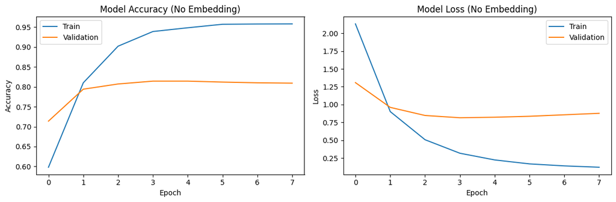

```python
plt.figure(figsize=(12, 4))

# 정확도 그래프
plt.subplot(1, 2, 1)
plt.plot(history.history['accuracy'], label='Train')
plt.plot(history.history['val_accuracy'], label='Validation')
plt.title('Model Accuracy (No Embedding)')
plt.ylabel('Accuracy')
plt.xlabel('Epoch')
plt.legend()

# 손실 그래프
plt.subplot(1, 2, 2)
plt.plot(history.history['loss'], label='Train')
plt.plot(history.history['val_loss'], label='Validation')
plt.title('Model Loss (No Embedding)')
plt.ylabel('Loss')
plt.xlabel('Epoch')
plt.legend()

plt.tight_layout()
plt.show()
```

[figure not shown]

```python
models = ['DNN', 'LSTM']
accuracy = [0.7742, 0.7811]
precision = [0.6342, 0.6486]
recall = [0.5494, 0.5582]
f1 = [0.5629, 0.5791]

x = np.arange(len(models))
width = 0.2

plt.figure(figsize=(12, 6))
plt.bar(x - width*1.5, accuracy, width, label='Accuracy', color='#3498db')
plt.bar(x - width/2, precision, width, label='Precision', color='#2ecc71')
plt.bar(x + width/2, recall, width, label='Recall', color='#e74c3c')
plt.bar(x + width*1.5, f1, width, label='F1 Score', color='#f39c12')

plt.ylabel('Score', fontsize=12)
plt.title('Performance Comparison: DNN vs LSTM', fontsize=14, fontweight='bold')
plt.xticks(x, models, fontsize=12, fontweight='bold')
plt.legend(fontsize=11)
plt.grid(axis='y', linestyle='--', alpha=0.7)
plt.ylim(0, 1.0)

for i, v in enumerate(accuracy):
    plt.text(i - width*1.5, v + 0.02, f'{v:.4f}', ha='center', fontsize=9)

for i, v in enumerate(precision):
    plt.text(i - width/2, v + 0.02, f'{v:.4f}', ha='center', fontsize=9)

for i, v in enumerate(recall):
    plt.text(i + width/2, v + 0.02, f'{v:.4f}', ha='center', fontsize=9)

for i, v in enumerate(f1):
    plt.text(i + width*1.5, v + 0.02, f'{v:.4f}', ha='center', fontsize=9)

plt.tight_layout()
plt.show()
```

### 5. 결론

[figure not shown]